# Notebook

```python
!date
```

```
Fri Jan 10 06:11:13 PST 2014
```

I checked in with David Phillips about what he did on this topic, and determined that it is worthy of some additional investigation on my part.

```
From: David Phillips
Sent: Wednesday, January 08, 2014 10:33 PM
To: Abraham D. Flaxman
Subject: RE: GC redistribution with MCD data
```

Hey Abie,

First of all, this project has been put on the back-burner, mostly because I think nobody wants to update the garbage code redistribution code again.

Anyway, what I did was make a ton of dummy variables and used them in many logistic regressions. The outcome was whether or not cause X was the underlying cause in a given death certificate, and the explanatory variables were dummy variables for each cause in each other field on the death certificate. So, there were about 500 dummies (all of the GBD causes of death plus all ICD10 garbage codes) multiplied by the 20-something fields. I also tinkered around with age and country fixed effects, but never got far enough to evaluate performance. A separate regression was run for each of the different possible outcome variables; each of the 235 GBD causes of death. I fit the regression amongst only observations that didn’t have garbage as underlying, and then predicted amongst the garbage observations. The results were then stored such that each garbage observation was given a distinct probability of actually being each of the GBD causes. I then summed probabilities across all observations and redistributed garbage with respect to the proportions represented by the sums. I also tried just assigning each observation to its most likely cause.

The main problem I ran into was complete (or quasi-complete) separation, which, in hindsight, we should have seen coming given the abnormal number of explanatory variables and the fact that each variable was quite sparse (just a few 1’s amongst millions of 0’s). I aggregated garbage codes and tried again, but there were still way too many sparse variables to be workable. Kyle’s idea was to also aggregate GBD codes, and then we would do some kind of cascading thing, but I haven’t tried to tackle that yet.

Because thousands of dummy variables is a silly way to store a few categorical variables, I decided to run random forest. This worked fine, but the results were still quite contrary to Mohsen and Chris’ expectations, which is basically where we all lost hope.

```
That’s the whole story! What are you working on?
David
```

For a qualitative validation, he made a plot of redistribution for septicimia garbage stacked by age group, which showed implausible results, such as most septicimia redistributed to RHD. I wonder what my redistribution plot looks like (it should be a table, not a plot, also).

```python
import pandas as pd, glob
dname = '/clustertmp/abie/USA_MCD/'
```

# Setup feature engineering code upfront

```python
from sklearn.feature_extraction.text import HashingVectorizer
vectorizer = HashingVectorizer(ngram_range=(1,2))


import sklearn.neighbors
clf = sklearn.neighbors.KNeighborsClassifier(n_neighbors=10, weights='uniform')

# TODO: go straight from DataFrame to sparse array (should be faster)
def extract_training_str(s):
    t = ' '.join([s['cause_entity%d'%(i+1)] for i in range(20)])
    return t
```

# Load a chunk of data

```python
!ls $dname | grep all |sort |head
```

```
all-00-1-1979.csv
all-00-1-1984.csv
all-00-1-1989.csv
all-00-1-1994.csv
all-00-1-1999.csv
all-00-1-2004.csv
all-00-2-1979.csv
all-00-2-1984.csv
all-00-2-1989.csv
all-00-2-1994.csv
```

```python
glob.glob(dname + 'all-0*-*-198*.csv')
```

```
['/clustertmp/abie/USA_MCD/all-05-2-1989.csv',
 '/clustertmp/abie/USA_MCD/all-01-2-1989.csv',
 '/clustertmp/abie/USA_MCD/all-00-1-1984.csv',
 '/clustertmp/abie/USA_MCD/all-01-1-1984.csv',
 '/clustertmp/abie/USA_MCD/all-05-1-1984.csv',
 '/clustertmp/abie/USA_MCD/all-00-2-1989.csv',
 '/clustertmp/abie/USA_MCD/all-00-2-1984.csv',
 '/clustertmp/abie/USA_MCD/all-01-1-1989.csv',
 '/clustertmp/abie/USA_MCD/all-05-1-1989.csv',
 '/clustertmp/abie/USA_MCD/all-00-1-1989.csv',
 '/clustertmp/abie/USA_MCD/all-05-2-1984.csv',
 '/clustertmp/abie/USA_MCD/all-01-2-1984.csv']
```

```python
age = '6*'
sex = '1'
year = '2004'
```

```python
%%time
# tell pandas not to do anything too smart with the cause lists
converters = {}
for i in range(20):
    converters['cause_entity%d'%(i+1)] = str
    converters['cause_record%d'%(i+1)] = str

converters['underlying_cause'] = str

df = pd.DataFrame()
for fname in glob.glob(dname + 'all-%s-%s-%s.csv'%(age,sex,year)):
    df = df.append(pd.read_csv(fname, converters=converters, low_memory=False), ignore_index=True, )
```

```
CPU times: user 25 s, sys: 4.82 s, total: 29.8 s
Wall time: 30.6 s
```

```python
df.shape #, df.columns
```

```
(1392451, 58)
```

# Groom the data, and make test and train sets

```python
import json
map_icd = json.load(file('map_icd.json'))
```

```python
df['cod'] = df.underlying_cause.map(map_icd)
```

```python
%%time
train_rows = {}
test_rows = {}

for j, df_j in df.groupby('cod'):
    #print j, len(df_j.index)

    if j != '_gc':
        train_rows[j] = list(df_j.index)
    else:
        # icd9 septicemia codes
        codes = '038 0380 0381 03810 03811 03812 03819 0382 0383 0384 03840 03841 03842 03843 03844 03849 0388 0389'.split()
        # icd10 septicemia codes
        codes += 'A41 A410 A4101 A4102 A411 A412 A413 A414 A415 A4150 A4151 A4152 A4153 A4159 A418 A4181 A4189 A419'.split()
        rows = df_j.underlying_cause.isin(codes)
        test_rows[j] = list(df_j[rows].index)
```

```
CPU times: user 11.6 s, sys: 193 ms, total: 11.8 s
Wall time: 11.8 s
```

```python
rows.shape, len(test_rows['_gc'])
```

```
((223385,), 18743)
```

```python
s = df.xs(test_rows['_gc'][0])
s[s!='']
```

```
age                                   65
cause_entity1                       A419
cause_entity2                       J189
cause_entity3                        N19
cause_entity4                       E149
cause_record1                       A419
cause_record2                       E149
cause_record3                       J189
cause_record4                        N19
data_year                           2004
day_of_week                            2
marital                                M
month_death                            1
number_of_entity_axis_conditions       4
number_of_record_axis_conditions       4
occurence_county                     NaN
occurence_county_fips                670
occurence_state                      NaN
occurence_state_fips                  VA
place_of_injury                      NaN
placedeath                             1
record_type                            2
resident_status                        2
sex                                    1
state_birth                           NC
underlying_cause                    A419
cod                                  _gc
Name: 3, dtype: object
```

# Train

```python
%%time
y_train = []
X_train_str = []

for j, rows_j in train_rows.iteritems():
    if len(rows_j) == 0:
        continue

    y_train += [j]*len(rows_j)
    X_train_str += list(df.ix[rows_j].apply(extract_training_str, axis=1))

X_train = vectorizer.transform(X_train_str)
```

```
CPU times: user 7min 43s, sys: 474 ms, total: 7min 43s
Wall time: 7min 44s
```

```python
X_train.shape, X_train_str[:15]
```

```
((1169066, 1048576),
 ['I469 R092 T174 G473 I500 E669 W80             ',
  'I490 R090 T179 W80 R13 Q046 R568 F319 M819           ',
  'A419 T179 W80 J449 I739 N19              ',
  'T71 W79 T179 F03 T179               ',
  'T179 W79 T179                 ',
  'T179 W79 T179 R568 T179               ',
  'I429 N19 T179 W80 R31               ',
  'G931 T179 W80 T179                ',
  'G931 T179 W79 T179 I48 J449 I255             ',
  'J189 T179 W80 R13 F03 I48              ',
  'J969 R11 T179 W78 Q909               ',
  'A419 G931 T179 W80                ',
  'T179 W79 T179 T179                ',
  'T179 W80 T179                 ',
  'I499 T179 W80 J960                '])
```

```python
%time clf.fit(X_train, y_train)
```

```
CPU times: user 724 ms, sys: 63 ms, total: 787 ms
Wall time: 788 ms
```

```
KNeighborsClassifier(algorithm='auto', leaf_size=30, metric='minkowski',
           n_neighbors=10, p=2, weights='uniform')
```

# Test

```python
%%time
X_test = {}

for j, rows_j in test_rows.iteritems():
    if len(rows_j) == 0:
        continue
    X_test_str = df.ix[rows_j].apply(extract_training_str, axis=1)

    X_test[j] = vectorizer.transform(X_test_str)

    #print j, len(rows_j), X_test[j].shape
```

```
CPU times: user 7.56 s, sys: 4 ms, total: 7.56 s
Wall time: 7.57 s
```

```python
# how long does it take to make a single prediction?
%timeit clf.predict_proba(X_test[j][2])
```

```
1 loops, best of 3: 392 ms per loop
```

```python
X_test.keys()
```

```
[u'_gc']
```

```python
X_test[j].shape
```

```
(18743, 1048576)
```

```python
%%time
y_pred = {}

for j in X_test.keys():
    y_pred[j] = {}
    # TODO: make this faster, by predicting chunks together
    # (predicting all together was giving memory error)
    for r in range(X_test[j].shape[0]):
        y_pred[j][r] = clf.predict_proba(X_test[j][r])
    #print j, y_pred[j].shape
```

```
CPU times: user 1h 54min 27s, sys: 6min 1s, total: 2h 29s
Wall time: 2h 51s
```

```python
j = '_gc'
for i in range(4):
    s = pd.Series(y_pred[j][i][0], index=clf.classes_)
    print s[s>0].order(ascending=False)
    print
```

```
diabetes        0.9
ckd_diabetes    0.1
dtype: float64

digest_ibd               0.3
neo_myeloma              0.2
neo_liver                0.1
neo_esophageal_cancer    0.1
neo_bladder_cancer       0.1
infectious               0.1
cirrhosis                0.1
dtype: float64

diabetes        0.8
endo_obesity    0.1
digest_ileus    0.1
dtype: float64

resp_interstitial      0.2
neo_lung_cancer        0.2
resp_copd              0.1
neo_prostate_cancer    0.1
neo_myeloma            0.1
neo_leukemia           0.1
ckd                    0.1
cirrhosis              0.1
dtype: float64
```

```python
%%time
j = '_gc'
s = pd.Series(zeros_like(clf.classes_, dtype=float), index=clf.classes_)
for i in range(X_test[j].shape[0]):
    s += pd.Series(y_pred[j][i][0], index=clf.classes_)
```

```
CPU times: user 8.18 s, sys: 2 ms, total: 8.19 s
Wall time: 8.21 s
```

```python
#s.order(ascending=False)
```

```python
round_(100*(s.order(ascending=False) / s.sum()), 2).head(10)
```

```
cvd_ihd                  9.19
cirrhosis                8.60
diabetes                 7.70
ckd                      6.86
resp_copd                5.87
neo_lung_cancer          4.52
diarrhea_Clostridium     3.43
neo_colorectal_cancer    3.21
urinary_nephritis        3.18
digest_ibd               2.80
dtype: float64
```

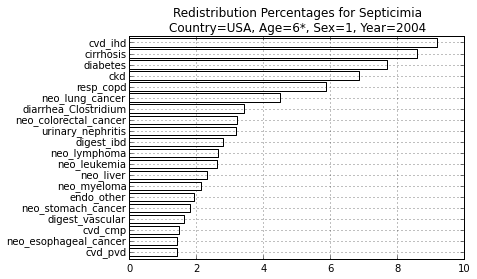

```python
figure(figsize=(6,4))
(100*(s.order(ascending=True) / s.sum())).tail(20).plot(kind='barh', fc='none')
title('Redistribution Percentages for Septicimia\nCountry=USA, Age=%s, Sex=%s, Year=%s' % (age, sex, year))
```

David thinks that this cvd_ihd is not good, and it seems he is right.